# Project: Investigate a Soccer Database

- Introduction
- Data Wrangling
- Exploratory Data Analysis
- Conclusions

## Introduction

### **Soccer Database from Kaggle**

This soccer database comes from Kaggle and is well suited for data analysis and machine learning. It contains data for soccer matches, players, and teams from several European countries from 2008 to 2016. This dataset is quite extensive, and we encourage you to read more about it here.

- The database is stored in a SQLite database.

Through this report, we will wrangle, clean and explore the data to answer some interesting questions :

1. **Is there a relationship between (Points) and (Goals for and Goals against) over different seasons ?**
2. **What is the performance of each team over season ?**
3. **Which teams have the worst defense for each season?**
4. **Which teams have the best defense for each season?**
5. **Which teams have the worst attack for each season?**
6. **Which teams have the best attack for each season?**

Now, let's start our journy !

```python
import pandas as pd
import numpy as np
import matplotlib.pyplot as plt
import seaborn as sns
import warnings
warnings.filterwarnings('ignore')
% matplotlib inline
```

```python
team = pd.read_csv('/content/Team.csv')
match = pd.read_csv('/content/drive/My Drive/Match.csv')
league = pd.read_csv('/content/League.csv')
country = pd.read_csv('/content/Country.csv')
```

## Data Wrangling

- In this phase , we gonna merge county, league and match table together.
- This will give us the whole statistics for all matches played from 2009 to 2016 in all leagues, but we will have interest just in **England Premier League** teams over different seasons.
- At the end of this phase, we will be having a very usefull dataframe which has
  - team
  - season
  - goals_for
  - goals_against
  - points

```python
# Here we gonna merge country and league tables to map each league to its country
league_country = pd.merge(league,country, left_on='country_id', right_on='id')
league_country.head()
```

|  | id_x | country_id | name_x | id_y | name_y |
| --- | --- | --- | --- | --- | --- |
| 0 | 1 | 1 | Belgium Jupiler League | 1 | Belgium |
| 1 | 1729 | 1729 | England Premier League | 1729 | England |
| 2 | 4769 | 4769 | France Ligue 1 | 4769 | France |
| 3 | 7809 | 7809 | Germany 1. Bundesliga | 7809 | Germany |
| 4 | 10257 | 10257 | Italy Serie A | 10257 | Italy |

```python
# Now we gonna drop the useless columns (id_y, country_id) and rename the columns to meaningful names
league_country.drop(['id_y', 'country_id'], axis = 1, inplace=True)
league_country.rename(columns={'id_x': 'league_id','name_x':'league','name_y':'country'}, inplace=True)
```

```python
# Here we will merge the new league table with the match table to get each match mapped to its league
league_match = pd.merge(league_country,match, on='league_id')
league_match.head(2)
```

|  | league_id | league | country | id | country_id | season | stage | date | match_api_id | home_team_api_id | away_team_api_id | home_team_goal | away_team_goal | home_player_X1 | home_player_X2 | home_player_X3 | home_player_X4 | home_player_X5 | home_player_X6 | home_player_X7 | home_player_X8 | home_player_X9 | home_player_X10 | home_player_X11 | away_player_X1 | away_player_X2 | away_player_X3 | away_player_X4 | away_player_X5 | … |
| --- | --- | --- | --- | --- | --- | --- | --- | --- | --- | --- | --- | --- | --- | --- | --- | --- | --- | --- | --- | --- | --- | --- | --- | --- | --- | --- | --- | --- | --- | --- |
| 0 | 1 | Belgium Jupiler League | Belgium | 1 | 1 | 2008/2009 | 1 | 2008-08-17 00:00:00 | 492473 | 9987 | 9993 | 1 | 1 | NaN | NaN | NaN | NaN | NaN | NaN | NaN | NaN | NaN | NaN | NaN | NaN | NaN | NaN | NaN | NaN | … |
| 1 | 1 | Belgium Jupiler League | Belgium | 2 | 1 | 2008/2009 | 1 | 2008-08-16 00:00:00 | 492474 | 10000 | 9994 | 0 | 0 | NaN | NaN | NaN | NaN | NaN | NaN | NaN | NaN | NaN | NaN | NaN | NaN | NaN | NaN | NaN | NaN | … |

2 rows × 117 columns

```python
# Since we merged the two dataframs we no longer need ids columns so we gonna drop them
league_match.drop(['league_id','country_id'], axis = 1, inplace=True)
```

```python
# Now, we will add team table to match table to map the teams to there matches through all seasons
team_match = pd.merge(team, league_match, left_on='team_api_id', right_on='home_team_api_id')
team_match.head(2)
```

|  | id_x | team_api_id | team_fifa_api_id | team_long_name | team_short_name | league | country | id_y | season | stage | date | match_api_id | home_team_api_id | away_team_api_id | home_team_goal | away_team_goal | home_player_X1 | home_player_X2 | home_player_X3 | home_player_X4 | home_player_X5 | home_player_X6 | home_player_X7 | home_player_X8 | home_player_X9 | home_player_X10 | home_player_X11 | away_player_X1 | away_player_X2 | … |
| --- | --- | --- | --- | --- | --- | --- | --- | --- | --- | --- | --- | --- | --- | --- | --- | --- | --- | --- | --- | --- | --- | --- | --- | --- | --- | --- | --- | --- | --- | --- |
| 0 | 1 | 9987 | 673.0 | KRC Genk | GEN | Belgium Jupiler League | Belgium | 1 | 2008/2009 | 1 | 2008-08-17 00:00:00 | 492473 | 9987 | 9993 | 1 | 1 | NaN | NaN | NaN | NaN | NaN | NaN | NaN | NaN | NaN | NaN | NaN | NaN | NaN | … |
| 1 | 1 | 9987 | 673.0 | KRC Genk | GEN | Belgium Jupiler League | Belgium | 29 | 2008/2009 | 12 | 2008-11-15 00:00:00 | 492583 | 9987 | 9999 | 1 | 1 | NaN | NaN | NaN | NaN | NaN | NaN | NaN | NaN | NaN | NaN | NaN | NaN | NaN | … |

2 rows × 120 columns

```python
# As we did above we gonna remove useless column ids and team short name and rename teams name column
team_match.drop(['id_x','team_api_id','team_fifa_api_id','team_short_name','id_y', 'match_api_id'], axis = 1, inplace=True)
team_match.rename(columns={'team_long_name':'team'}, inplace=True)
```

```python
# Here we will replace each team id to the real name of the team so we can get meaningful insights about each team over seasons
team_names = dict(zip(team.team_api_id, team.team_long_name))
team_match.replace(team_names, inplace=True)
```

```python
# Now we gonna give our columns meaningful names after replacing the values of them with teams
team_match.rename(columns={'home_team_api_id':'home_team','away_team_api_id':'away_team'}, inplace=True)
team_match.drop(['team'], axis=1, inplace=True)
```

```python
team_match.head(2)
```

|  | league | country | season | stage | date | home_team | away_team | home_team_goal | away_team_goal | home_player_X1 | home_player_X2 | home_player_X3 | home_player_X4 | home_player_X5 | home_player_X6 | home_player_X7 | home_player_X8 | home_player_X9 | home_player_X10 | home_player_X11 | away_player_X1 | away_player_X2 | away_player_X3 | away_player_X4 | away_player_X5 | away_player_X6 | away_player_X7 | away_player_X8 | away_player_X9 | … |
| --- | --- | --- | --- | --- | --- | --- | --- | --- | --- | --- | --- | --- | --- | --- | --- | --- | --- | --- | --- | --- | --- | --- | --- | --- | --- | --- | --- | --- | --- | --- |
| 0 | Belgium Jupiler League | Belgium | 2008/2009 | 1 | 2008-08-17 00:00:00 | KRC Genk | Beerschot AC | 1 | 1 | NaN | NaN | NaN | NaN | NaN | NaN | NaN | NaN | NaN | NaN | NaN | NaN | NaN | NaN | NaN | NaN | NaN | NaN | NaN | NaN | … |
| 1 | Belgium Jupiler League | Belgium | 2008/2009 | 12 | 2008-11-15 00:00:00 | KRC Genk | KSV Roeselare | 1 | 1 | NaN | NaN | NaN | NaN | NaN | NaN | NaN | NaN | NaN | NaN | NaN | NaN | NaN | NaN | NaN | NaN | NaN | NaN | NaN | NaN | … |

2 rows × 113 columns

```python
# Now as we asked before , we will obtain the columns that will help us to answer our questions so we gonna choose the league , season, home_team, away_team,
# home team goals and home away goals . for home team goals and away home goals for each match we can get the points each team gained over seasons.
df = team_match[['league','season','home_team','away_team',
                 'home_team_goal','away_team_goal']]
```

```python
df.head()
```

|  | league | season | home_team | away_team | home_team_goal | away_team_goal |
| --- | --- | --- | --- | --- | --- | --- |
| 0 | Belgium Jupiler League | 2008/2009 | KRC Genk | Beerschot AC | 1 | 1 |
| 1 | Belgium Jupiler League | 2008/2009 | KRC Genk | KSV Roeselare | 1 | 1 |
| 2 | Belgium Jupiler League | 2008/2009 | KRC Genk | KSV Cercle Brugge | 3 | 2 |
| 3 | Belgium Jupiler League | 2008/2009 | KRC Genk | Sporting Charleroi | 1 | 0 |
| 4 | Belgium Jupiler League | 2008/2009 | KRC Genk | RAEC Mons | 2 | 0 |

```python
# Now we will calculate the points for each team per match as 3 points means that the home team win ,
# 0 points means that the home team lose and 1 means that it is tie
home_points = []
away_points = []
for index, row in df.iterrows():
    if(row['home_team_goal'] > row['away_team_goal']):
      home_points.append(3)
      away_points.append(0)
    elif(row['home_team_goal'] < row['away_team_goal']):
      home_points.append(0)
      away_points.append(3)
    else:
      home_points.append(1)
      away_points.append(1)

df['home_points'] = home_points
df['away_points'] = away_points
```

```python
df.head()
```

|  | league | season | home_team | away_team | home_team_goal | away_team_goal | home_points | away_points |
| --- | --- | --- | --- | --- | --- | --- | --- | --- |
| 0 | Belgium Jupiler League | 2008/2009 | KRC Genk | Beerschot AC | 1 | 1 | 1 | 1 |
| 1 | Belgium Jupiler League | 2008/2009 | KRC Genk | KSV Roeselare | 1 | 1 | 1 | 1 |
| 2 | Belgium Jupiler League | 2008/2009 | KRC Genk | KSV Cercle Brugge | 3 | 2 | 3 | 0 |
| 3 | Belgium Jupiler League | 2008/2009 | KRC Genk | Sporting Charleroi | 1 | 0 | 3 | 0 |
| 4 | Belgium Jupiler League | 2008/2009 | KRC Genk | RAEC Mons | 2 | 0 | 3 | 0 |

```python
# get_team_statistics function helps us to calculate goals for , goals against and points for all team in a selected league and season
# and it returns a dataframe contains all the teams in the selected season, the season, the goals for, the goals against and the points .

def get_team_statistics(df,season,league):
  premier_league = list(df[(df['league'] == league) &
                           (df['season'] == season)]['home_team'].unique())

  sum_goals = df.groupby(['league','season','home_team','away_team']).agg({'home_team_goal': 'sum', 'away_team_goal': 'sum'})
  sum_goals.reset_index(inplace= True)

  goals_over_season = []
  for team in premier_league:
    team_name = sum_goals[(sum_goals['league'] == league) &
                          (sum_goals['season'] == season) &
                          ((sum_goals['home_team'] == team)| (sum_goals['away_team'] == team))]

    team_home = team_name[team_name['home_team'] == team]
    team_away = team_name[team_name['away_team'] == team]
    goals_over_season.append(team_home['home_team_goal'].sum() + team_away['away_team_goal'].sum())

  goals_against_over_season = []
  for team in premier_league:
    team_name = sum_goals[(sum_goals['league'] == league) &
                          (sum_goals['season'] == season) &
                          ((sum_goals['home_team'] == team)| (sum_goals['away_team'] == team))]

    team_home = team_name[team_name['home_team'] != team]
    team_away = team_name[team_name['away_team'] != team]
    goals_against_over_season.append(team_home['home_team_goal'].sum() + team_away['away_team_goal'].sum())

  sum_points = df.groupby(['league','season','home_team','away_team']).agg({'home_points': 'sum', 'away_points': 'sum'})
  sum_points.reset_index(inplace= True)

  points_over_season = []
  for team in premier_league:
    team_name = sum_points[(sum_points['league'] == league) &
                           (sum_points['season'] == season) &
                           ((sum_points['home_team'] == team)|(sum_points['away_team'] == team))]
    team_home = team_name[team_name['home_team'] == team]
    team_away = team_name[team_name['away_team'] == team]
    points_over_season.append(team_home['home_points'].sum() + team_away['away_points'].sum())

  team_statistics = pd.DataFrame({'team': premier_league,'season':season,'goals_for':goals_over_season,'points':points_over_season,
                                  'goals_against':goals_against_over_season})
  return team_statistics
```

```python
# Here we checked for unique values of league column so we can get the names of the leagues contained in our database as we aim to select just one league
df['league'].unique()
```

```
array(['Belgium Jupiler League', 'England Premier League',
       'France Ligue 1', 'Germany 1. Bundesliga', 'Italy Serie A',
       'Netherlands Eredivisie', 'Poland Ekstraklasa',
       'Portugal Liga ZON Sagres', 'Scotland Premier League',
       'Spain LIGA BBVA', 'Switzerland Super League'], dtype=object)
```

```python
# Here we create dfs list that contains each season statistics for all teams in the season for the England Premier League.
dfs = []
seasons = ['2009/2010','2010/2011','2011/2012','2012/2013','2013/2014','2014/2015','2015/2016']
for season in seasons:
  teams_season_premier = get_team_statistics(df, season, league = 'England Premier League')
  dfs.append(teams_season_premier)
```

```python
# Now we gonna concat all the Dataframes in dfs list and then group the returned datafram by team and season so we can get the whole statistics
# for each team according to all seasons .
Premier_final = pd.concat(dfs)
```

```python
df = pd.DataFrame(Premier_final.groupby(['team','season'])[['goals_against','goals_for','points']].sum()).reset_index()
df.head(10)
```

|  | team | season | goals_against | goals_for | points |
| --- | --- | --- | --- | --- | --- |
| 0 | Arsenal | 2009/2010 | 41 | 83 | 75 |
| 1 | Arsenal | 2010/2011 | 43 | 72 | 68 |
| 2 | Arsenal | 2011/2012 | 49 | 74 | 70 |
| 3 | Arsenal | 2012/2013 | 37 | 72 | 73 |
| 4 | Arsenal | 2013/2014 | 41 | 68 | 79 |
| 5 | Arsenal | 2014/2015 | 36 | 71 | 75 |
| 6 | Arsenal | 2015/2016 | 36 | 65 | 71 |
| 7 | Aston Villa | 2009/2010 | 39 | 52 | 64 |
| 8 | Aston Villa | 2010/2011 | 59 | 48 | 48 |
| 9 | Aston Villa | 2011/2012 | 53 | 37 | 38 |

### Data Cleaning

- In this phase, we will check the data if there is any missing values.
- If there is any duplicates.
- The number of unique value in our dataset and so on ...

```python
# Now we will check if there is any missing values in our columns
df.isnull().sum()
```

```
team             0
season           0
goals_against    0
goals_for        0
points           0
dtype: int64
```

We can see that there is no missing value in our generated dataframe.

```python
# Let's check each column data type and see if it is correct or not
df.dtypes
```

```
team             object
season           object
goals_against     int64
goals_for         int64
points            int64
dtype: object
```

Now, we are sure that every column data type is correct.

```python
# check if there are any duplicates in our observation
sum(df.duplicated())
```

```
0
```

It seems that our dataframe has no duplicates

```python
# find the shape of our dataframe
df.shape
```

```
(140, 5)
```

The Dataset has 140 observarions and 5 columns.

```python
# Here we check for the number of unique values in each columns
df.nunique()
```

```
team             33
season            7
goals_against    50
goals_for        53
points           54
dtype: int64
```

We can see that we have 33 different teams in our dataset and 7 different seasons .

## Exploratory Data Analysis

- In this phase, we will explore our dataset using the appropriate plots to get the true relationships between our target variable (points) and our features (goals for and goals against).
- Exploratory Data Analysis will help us to answer our questions to get insights from the dataset.

# 1. Is there a relationship between (Points) and (Goals for and Goals against) over different seasons ?

```python
# feature_distribution_plot function plots a histogram of our continuous variable points, goals for, goals against
# using histplot function from seaborn
def feature_distribution_plot(df, feature):
  plt.figure(figsize=(15,6));
  sns.histplot(x = feature,data = df, bins= 30);
  plt.xlabel(feature, fontsize = 12);
  plt.title(feature + ' over Seasons', fontsize = 20);
  plt.grid();
```

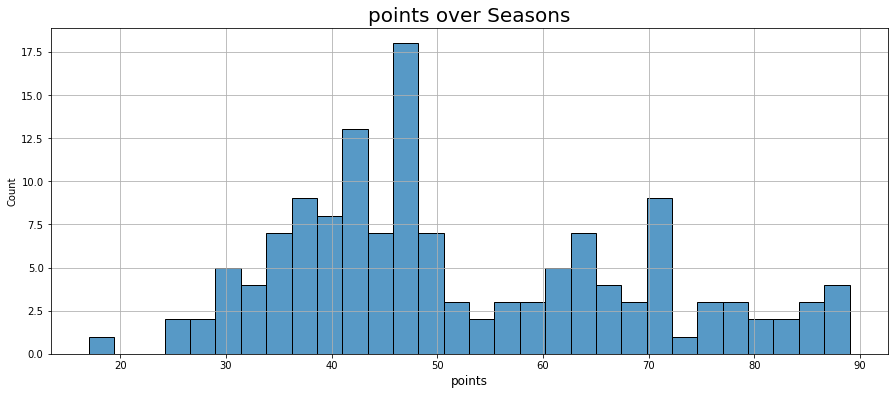

```python
feature_distribution_plot(df, 'points')
```

From the histogram we can the most points scored over all season is approximately from 30 points to 73 points .

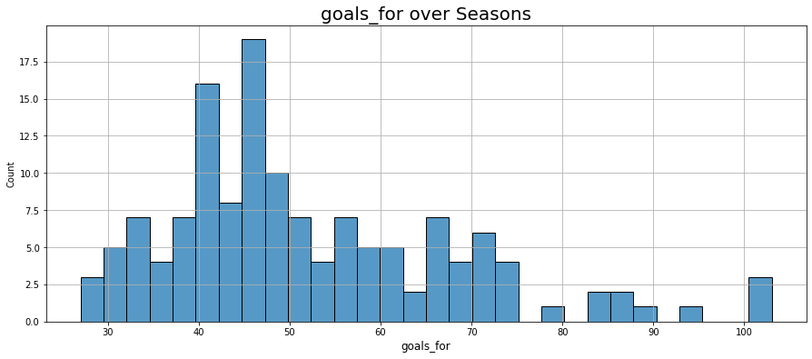

```python
feature_distribution_plot(df, 'goals_for')
```

From the histogram we can the most goals for scored over all season is approximately from 30 goals to 75 goals.

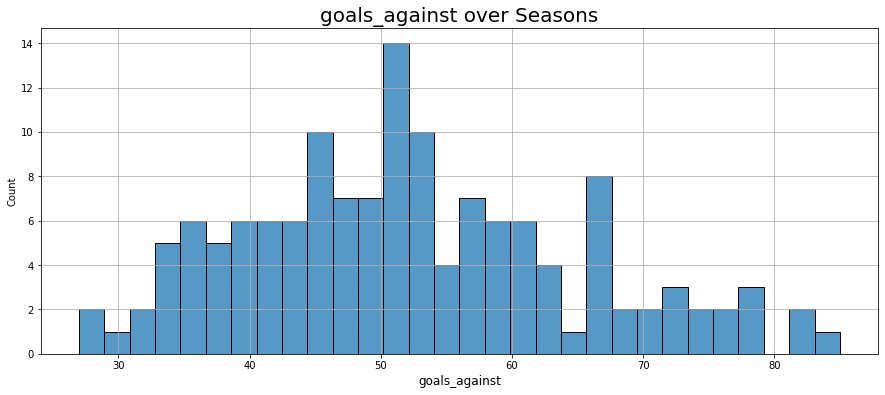

```python
feature_distribution_plot(df, 'goals_against')
```

From the histogram we can the most goals against scored over all season is approximately from 25 goals to 80 goals .

```python
# plot_relations_to_points function plots the relationship between points and any of our features
# using scatterplot function from seaborn
def plot_relations_to_points(df, feature):
  plt.figure(figsize=(15,6));
  sns.scatterplot(x = feature, y = 'points', data = df);
  plt.xlabel(feature +' '+ 'for all season', fontsize = 12);
  plt.ylabel('Points', fontsize = 12);
  plt.title(feature +' '+ 'vs Points for all season', fontsize = 20);
  plt.grid();
```

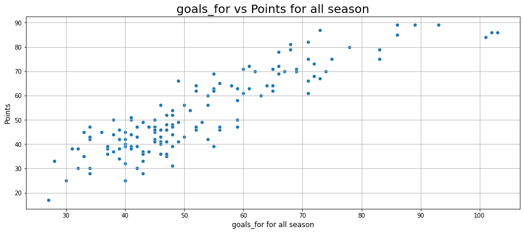

```python
plot_relations_to_points(df, 'goals_for')
```

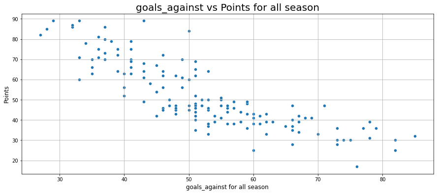

```python
plot_relations_to_points(df, 'goals_against')
```

- we can see from the two scatter plots above that there is a strong relationship between points and Goals for and Goals against features .
- The more Goals for the team score, the more points the team will gain and the opposite for points and Goals against.

# 2. **What is the performance of each team over season ?**

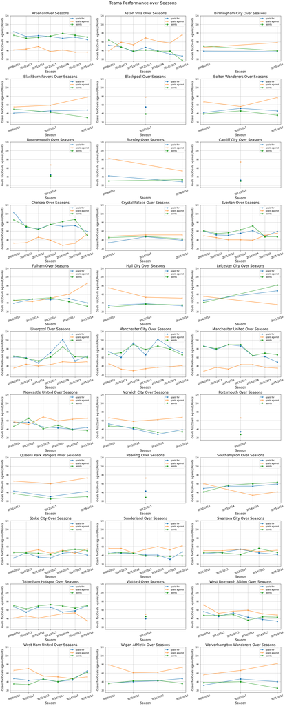

```python
# Now we will plot three indicators (points, goals for, goals against) from which we can get
# the differences of performance for each team for all seasons it participated in the league
team_index = range(33)
team_names = list(df['team'].unique())
fig = plt.figure(figsize=(20,50));
for team_num,team in zip(team_index,team_names):
  plt.subplot(11,3, team_num+1);
  plt.plot(df[df['team'] == team]['season'],df[df['team'] == team]['goals_for'],marker = 'o', label = 'goals for');
  plt.plot(df[df['team'] == team]['season'],df[df['team'] == team]['goals_against'],marker = 'x', label = 'goals against');
  plt.plot(df[df['team'] == team]['season'],df[df['team'] == team]['points'],marker = 's', label = 'points');
  plt.ylim(15,120);
  plt.grid();
  plt.legend();
  plt.xticks(rotation= 20, fontsize = 12);
  plt.xlabel('Season', fontsize = 15);
  plt.ylabel('Goals for/Goals against/Points', fontsize = 14);
  plt.title(''.join([team,' Over Seasons']), fontsize = 17);
fig.suptitle('Teams Performance over Seasons', size = 20);
plt.tight_layout();
fig.subplots_adjust(top = 0.96)
```

From the above plot, we can get different insights as to

- the number of seasons that each team participated in the England Premier League from 2009 to 2015
- the difference in performance from season to season for each team according to the points the team gained.

## 3. **Which teams have the worst defense for each season?**

```python
# defense_attack_over_seasons function help us to plot whether the best defense, the worst defense, the best attack, or the worst attack
# range_start and range_end determine exactly the number of teams we want to plot
def defense_attack_over_seasons(dfs, y, ylabel, title, suptitle, range_start, range_end):
  season_index = range(9)
  fig = plt.figure(figsize=(15,15));
  for num, season_teams in zip(season_index, dfs):
    season = str(season_teams['season'].unique())[2:-2]
    season_teams = season_teams.sort_values(y, ascending = False).iloc[range_start:range_end,:]
    plt.subplot(3,3,num+1);
    sns.barplot(x = 'team', y = y, data = season_teams);
    plt.xticks(rotation = 90);
    plt.xlabel('Team');
    plt.ylabel(ylabel);
    plt.title(title + ' ' + season+ ' Season');
  fig.suptitle(suptitle, size = 20);
  plt.tight_layout();
  fig.subplots_adjust(top=0.93)
```

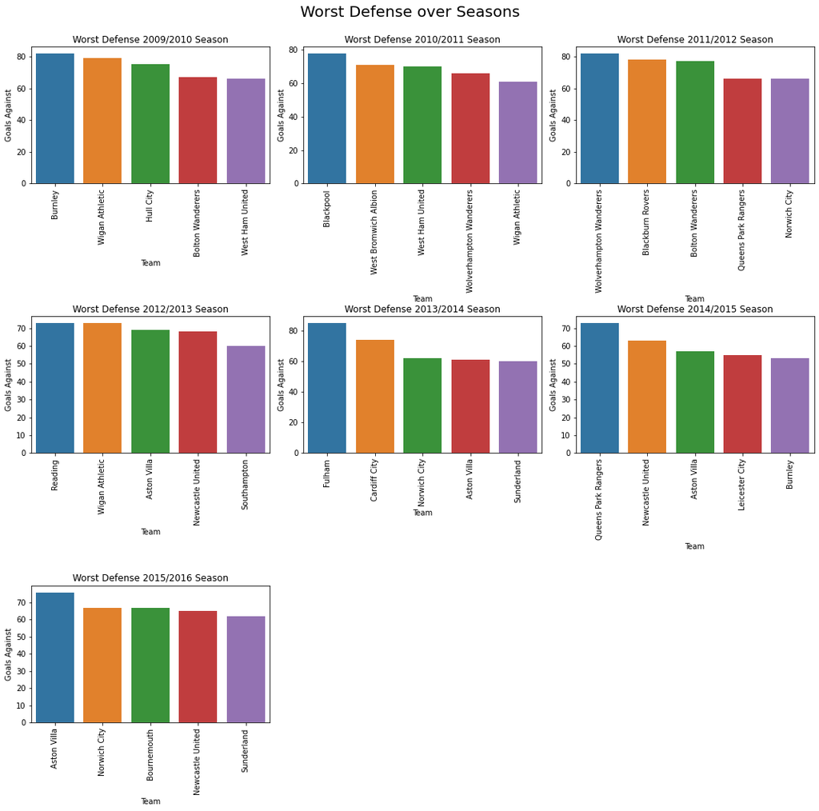

```python
# Here we gonna plot the worst 5 defenses for each season according to the goals each team received during the whole season
# the more the team receives goals, the worst the defense is
defense_attack_over_seasons(dfs, y = 'goals_against',ylabel= 'Goals Against',
                            title= 'Worst Defense',suptitle= 'Worst Defense over Seasons',
                            range_start=0, range_end= 5)
```

- From the plot above, we can get that
  1. The worst defense for 2009/2010 season is **Burnley** with about 82 goals received .
  2. The worst defense for 2010/2011 season is **Blackpool** with about 78 goals received .
  3. The worst defense for 2011/2012 season is **Wolverhampton Wanderers** with about 82 goals received .
  4. The worst defense for 2012/2013 season is **Reading** with about 72 goals received .
  5. The worst defense for 2013/2014 season is **Fulham** with about 85 goals received .
  6. The worst defense for 2014/2015 season is **Queens Park Rangers** with about 73 goals received .
  7. The worst defense for 2015/2016 season is **Aston Villa** with about 75 goals received .
- We can conclude that the worst defense over all seasons is Fulham with about 85 goals reveived .

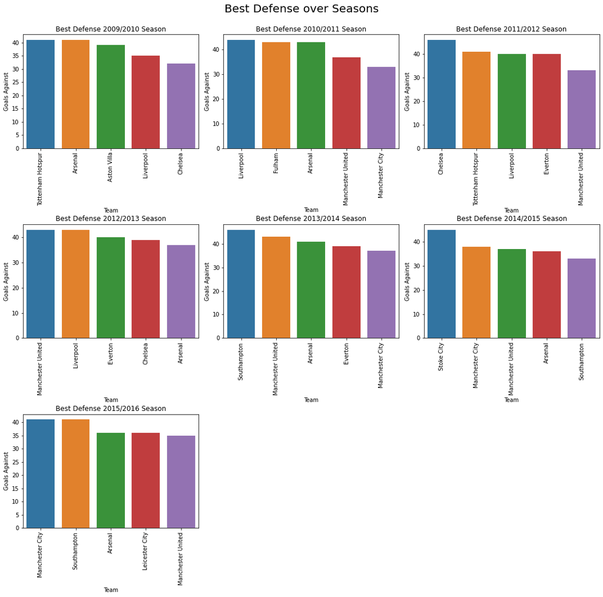

```python
# Here we gonna plot the best 5 defenses for each season according to the goals each team recieved during the whole season
# the less the team receives goals, the best the defense is
defense_attack_over_seasons(dfs, y = 'goals_against', ylabel='Goals Against',
                            title= 'Best Defense', suptitle= 'Best Defense over Seasons',
                            range_start=-6, range_end=-1)
```

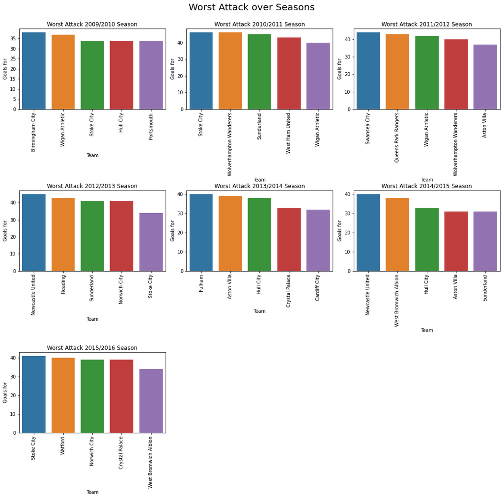

```python
# Here we gonna plot the worst 5 attacks for each season according to the goals each team scored during the whole season
# the less the team scored goals, the worst the attack is
defense_attack_over_seasons(dfs, y = 'goals_for', ylabel='Goals for',
                            title= 'Worst Attack', suptitle= 'Worst Attack over Seasons',
                            range_start=-6, range_end=-1)
```

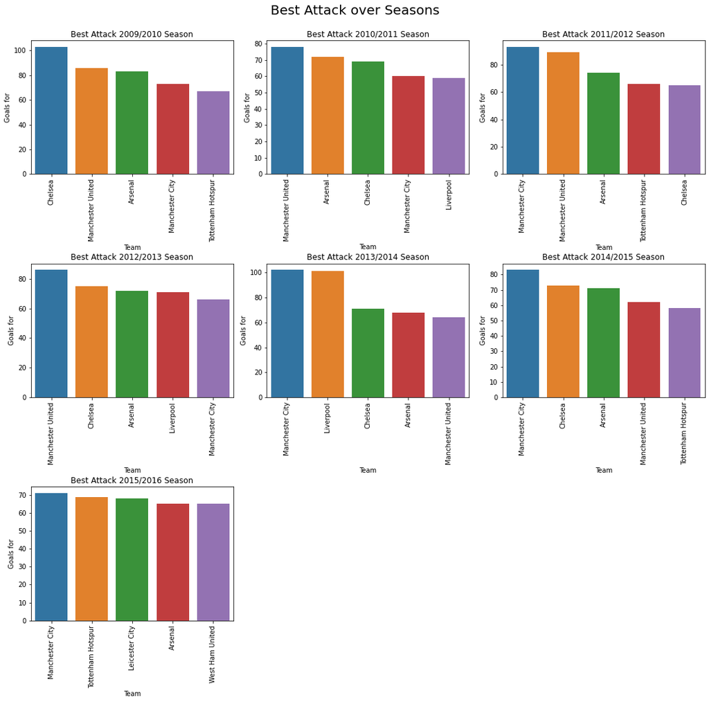

```python
# Here we gonna plot the best 5 attacks for each season according to the goals each team scored during the whole season
# the more the team scored goals, the best the attack is
defense_attack_over_seasons(dfs, y = 'goals_for', ylabel='Goals for',
                            title= 'Best Attack', suptitle= 'Best Attack over Seasons',
                            range_start=0, range_end=5)
```

## Conclusions

In conclusion , we have the answers for our questions .